# Research project: Final report

> Team 19 (Arsen Botsko, Anna Kryvulia, Levytskyi Taras)

# 1 Goal of the project

The goal of our project is to analyse the variables and events that influence the duration of air alarms.

## 1.1 Library imports

```r
library(MASS)
library(dplyr)
library(lubridate)
library(fitdistrplus)
library(kSamples)
library(mgcv)
```

# 2 Data description and analysis

```r
df <- read.csv("datasets/tg_parsed_alarms.csv")
data <- df$duration_min
data <- data[!is.na(data)]
data <- data[data > 0]
```

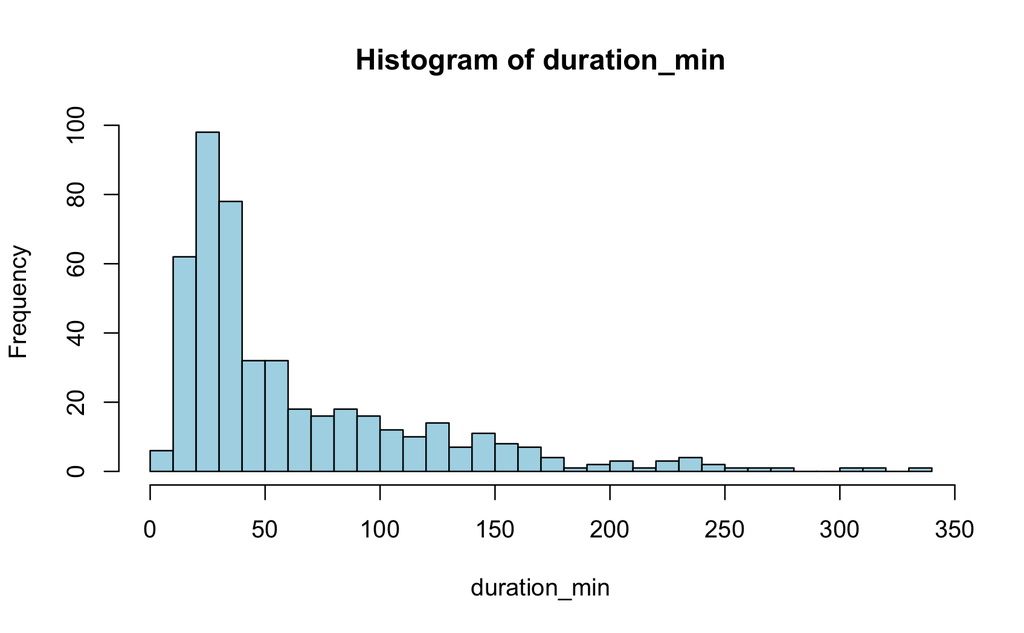

```r
hist(df$duration_min,
    breaks = 30,
    xlab = "duration_min",
    col = "lightblue",
    main = "Histogram of duration_min")
```

Histogram of durations of air alarms clearly tell us, that its distribution is not normal (it is not symetrical and right-skewed). We suggest such list of distributions to be tested: exponential, gamma and lognormal*.

(Look at the end of report for detailed info about lognormal distribution)

Let’s test these hypotheses using a parametric goodness-of-fit approach*.

Using a full goodness-of-fit approach is better than using only the Kolmogorov–Smirnov test, because KS evaluates only the maximum difference between the empirical and theoretical CDF, while ignoring the overall shape, tail behavior, and model complexity. In contrast, the goodness-of-fit framework combines several complementary statistics (KS, Cramer–von Mises, Anderson–Darling) together with information criteria such as AIC/BIC, which allow fair comparison between distributions with different numbers of parameters. This gives a clearer and more balanced understanding of which distribution fits the data best.

(More detailed info is also provided at the end of report)

```r
fit_exp  <- fitdist(data, "exp")
fit_gamma <- fitdist(data, "gamma")
fit_lnorm <- fitdist(data, "lnorm")


gofstat(list(fit_exp, fit_gamma, fit_lnorm))
```

```
Goodness-of-fit statistics
                              1-mle-exp 2-mle-gamma 3-mle-lnorm
Kolmogorov-Smirnov statistic  0.1742662   0.1323268  0.09352513
Cramer-von Mises statistic    2.4326414   2.0689968  0.85553106
Anderson-Darling statistic   16.5183625  11.1464891  4.76486380

Goodness-of-fit criteria
                               1-mle-exp 2-mle-gamma 3-mle-lnorm
Akaike's Information Criterion  4840.788    4779.686    4721.468
Bayesian Information Criterion  4844.941    4787.991    4729.774
```

The lognormal distribution provides the best fit to the empirical data.

duration_min ~ Lognormal($\mu$, $\sigma ^2$),

where the parameters $\mu$ and $\sigma$ are estimated using the maximum likelihood method.

```r
mu <- fit_lnorm$estimate["meanlog"]
cat('mu = ', mu, "\n")
```

```
mu =  3.817803
```

```r
sigma <- fit_lnorm$estimate["sdlog"]
cat("sigma = ", sigma)
```

```
sigma =  0.8039982
```

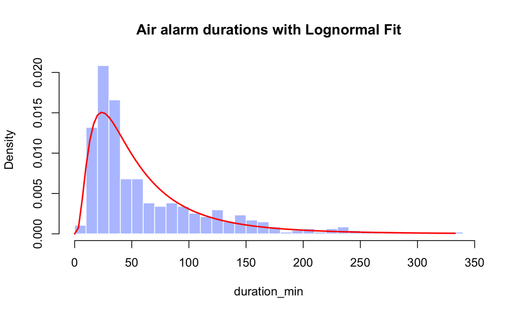

```r
hist(data,
     breaks = 30,
     freq = FALSE,
     col = rgb(0.2, 0.4, 1, 0.4),
     border = "white",
     main = "Air alarm durations with Lognormal Fit",
     xlab = "duration_min",
     ylab = "Density")

curve(dlnorm(x, meanlog = mu, sdlog = sigma),
      from = 0, to = max(data),
      add = TRUE,
      col = "red",
      lwd = 2)
```

# 3 Duration dependences on different parameters

## 3.1 Date

We want to know, whether duration of air alarm depends on the date when it started. Because we have over 400 values of duration, we will group them by month and calculate the average duration of air alarm for each month

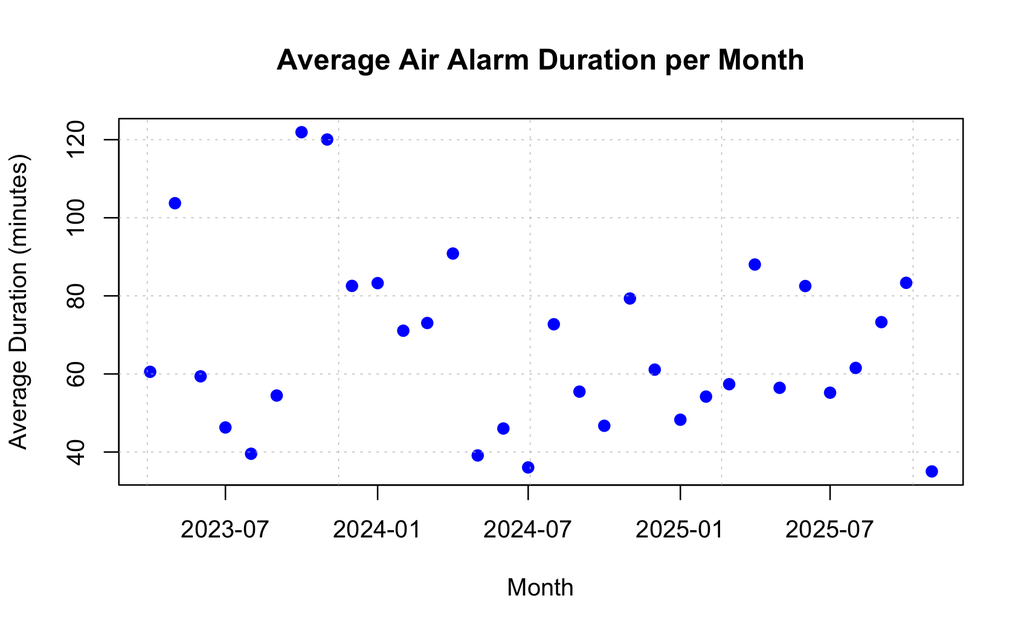

```r
df$started <- sub("\\+00:00$", "", df$started)
df$started <- as.POSIXct(df$started, format = "%Y-%m-%d %H:%M:%S", tz = "UTC")

monthly_mean <- df %>%
  mutate(month = floor_date(started, "month")) %>%
  group_by(month) %>%
  summarise(duration_min = mean(duration_min, na.rm = TRUE)) %>%
  arrange(month)

plot(monthly_mean$month, monthly_mean$duration_min,
     pch = 19,
     main = "Average Air Alarm Duration per Month",
     xlab = "Month",
     ylab = "Average Duration (minutes)",
     col = "blue"
)

grid(col = "gray", lty = 3, lwd = 0.5)
```

Visualy, we cannot see any dependence. Values are very spread around the plot, so it makes no sense to continue testing and build linear regression with this data.

## 3.2 Year

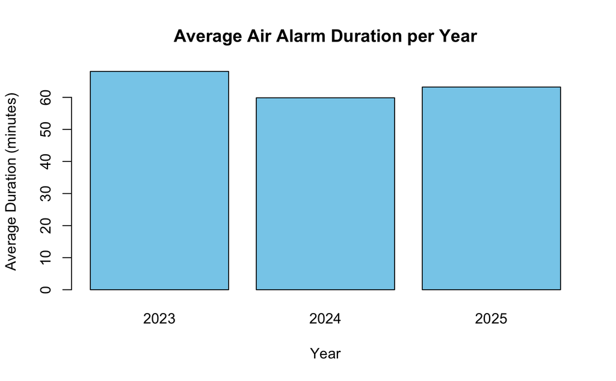

```r
df$started <- as.POSIXct(df$started)

yearly_mean <- df %>%
  mutate(year = as.integer(format(started, "%Y"))) %>%
  group_by(year) %>%
  summarise(duration_min = mean(duration_min, na.rm = TRUE)) %>%
  arrange(year)

barplot(
  yearly_mean$duration_min,
  names.arg = yearly_mean$year,
  col = "skyblue",
  main = "Average Air Alarm Duration per Year",
  xlab = "Year",
  ylab = "Average Duration (minutes)"
)
```

It is not visibly clear whether dependence between year and duration exists. To test dependence between year of alarm and its duration we use 2 approaches Firstly, for or each air year we test such hypothesis, using t-test(because variance of data is unknown):

> $H_0: \mu = \mu_{\text{year}}$, $\quad H_1: \mu \neq \mu_{\text{year}}$

where $\mu$ is the mean of the whole data, and $\mu_{\text{year}}$ is the sample mean of the year Secondly, we use Kolgomorov-Smirnov test, to compare e.c.d.f. of durations with some specific year to e.c.d.f. of the all durations > $H_0 : F_{\text{year}} = F$ > $H_1 : F_{\text{year}} \not= F_y$

```r
df$year <- as.integer(format(df$started, "%Y"))

y_all <- df$duration_min

for (yr in sort(unique(df$year))) {

  x <- df$duration_min[df$year == yr]
  y <- df$duration_min[df$year != yr]

  # t-test
  t_test <- t.test(x, y, alternative = "two.sided")
  pval_t <- format(t_test$p.value, scientific = FALSE)

  # KS-test
  ks_test <- suppressWarnings(ks.test(x, y, alternative = "two.sided"))
  pval_ks <- format(ks_test$p.value, scientific = FALSE)

  cat("Year:", yr, "\n")
  cat("  t-test p =", pval_t, "\n")
  cat("  KS test p =", pval_ks, "\n\n")
}
```

```
Year: 2023
  t-test p = 0.2008535
  KS test p = 0.000990419

Year: 2024
  t-test p = 0.2570869
  KS test p = 0.368041

Year: 2025
  t-test p = 0.9890483
  KS test p = 0.03475658
```

For 2023 and 2025 the KS test gives small p-values, indicating that the distribution of durations in these years differs from the overall distribution. However, for all years the t-test p-values are large, so we cannot reject H_0 regarding equality of means. For 2024 both tests show large p-values, meaning no detectable difference from the overall dataset. In general, we observe some dependence between the year and the distribution of alarm durations, but not in their mean values.  
## Weekday

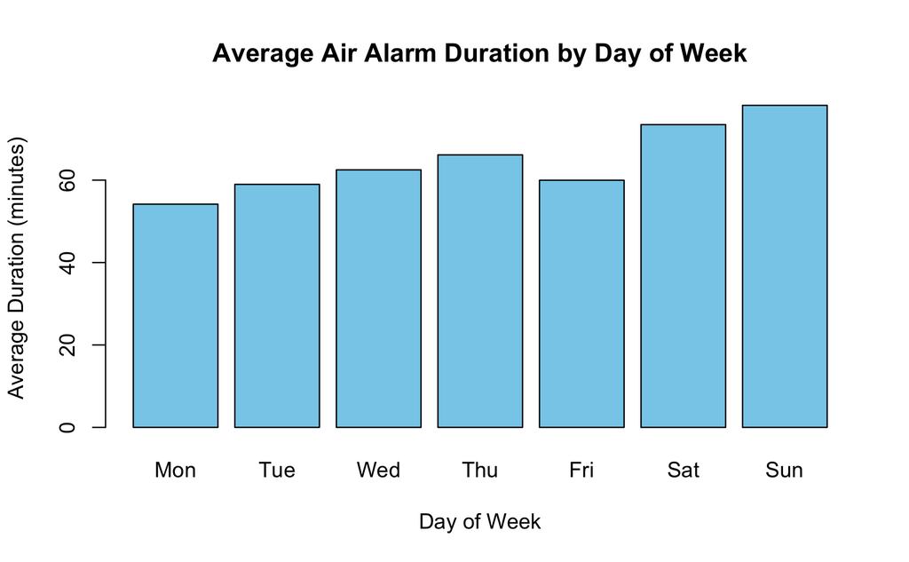

```r
df$weekday <- (as.integer(strftime(df$started, "%u")) - 1)

weekday_mean <- aggregate(df$duration_min,
                          by = list(weekday = df$weekday),
                          FUN = mean, na.rm = TRUE)
colnames(weekday_mean)[2] <- "duration_min"

weekday_mean <- weekday_mean[order(weekday_mean$weekday), ]


weekday_labels <- c("Mon", "Tue", "Wed", "Thu", "Fri", "Sat", "Sun")
weekday_mean$weekday_name <- weekday_labels[weekday_mean$weekday + 1]

barplot(
    weekday_mean$duration_min,
    names.arg = weekday_mean$weekday_name,
    col = "skyblue",
    main = "Average Air Alarm Duration by Day of Week",
    xlab = "Day of Week",
    ylab = "Average Duration (minutes)"
)
```

On the weekendі we see some increase of the average duration. Lets test this hypotheses of dependence on weekday by building linear regression model. $H_0$ : b = 0 $H_1$ : b $\neq$ 0

```r
model <- lm(weekday_mean$duration_min ~ weekday_mean$weekday)
summary(model)
```

```
Call:
lm(formula = weekday_mean$duration_min ~ weekday_mean$weekday)

Residuals:
       1        2        3        4        5        6        7
-0.05316  1.24017  1.24176  1.36369 -8.30696  1.67395  2.84056

Coefficients:
                     Estimate Std. Error t value Pr(>|t|)
(Intercept)           54.2184     2.8064  19.319 6.85e-06 ***
weekday_mean$weekday   3.5160     0.7784   4.517   0.0063 **
---
Signif. codes:  0 ‘***’ 0.001 ‘**’ 0.01 ‘*’ 0.05 ‘.’ 0.1 ‘ ’ 1

Residual standard error: 4.119 on 5 degrees of freedom
Multiple R-squared:  0.8032,    Adjusted R-squared:  0.7638
F-statistic:  20.4 on 1 and 5 DF,  p-value: 0.006299
```

By p-value = 0.0063, which is lower than most commonly used significance levels(.1, .05, .01), we can reject $H_0$. This and high R-squared = 0.8032 prove that dependence between day of the week and duration of alarm is significant.

## 3.3 Start hour

```r
df$hour <- as.integer(format(df$started, "%H"))

hourly <- aggregate(df$duration_min,
                    by = list(hour = df$hour),
                    FUN = mean, na.rm = TRUE)

colnames(hourly)[2] <- "duration_min"

hourly <- hourly[order(hourly$hour), ]

plot(hourly$hour, hourly$duration_min,
     pch = 19,
     cex = 0.8,
     main = "Average Alarm Duration by Start Hour",
     xlab = "Start Hour of Day",
     ylab = "Average Duration (minutes)",
     xaxt = "n"             # turn off default x-axis ticks
)

axis(1, at = 0:23)
```

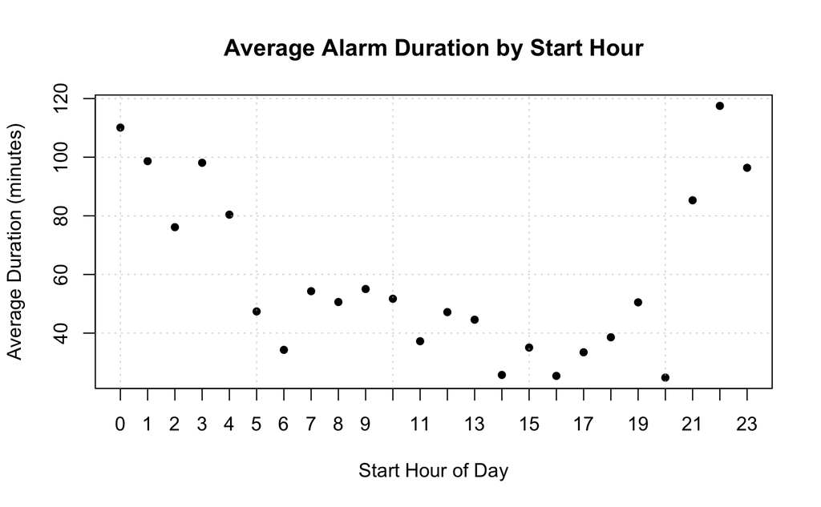

```r
grid(col = "gray", lty = 3, lwd = 0.5)
```

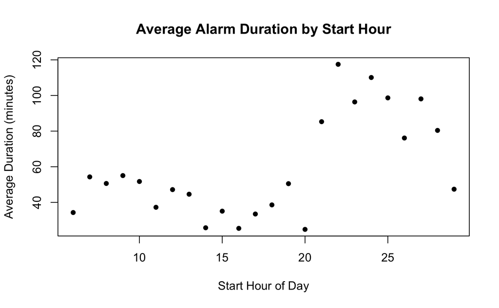

```r
df$hour <- as.integer(format(df$started, "%H"))
df$hour[df$hour < 6] <- df$hour[df$hour < 6] + 24

hourly <- aggregate(df$duration_min,
                    by = list(hour = df$hour),
                    FUN = mean, na.rm = TRUE)

colnames(hourly)[2] <- "duration_min"

hourly <- hourly[order(hourly$hour), ]

plot(hourly$hour, hourly$duration_min,
     pch = 19,
     cex = 0.8,
     main = "Average Alarm Duration by Start Hour",
     xlab = "Start Hour of Day",
     ylab = "Average Duration (minutes)"
)
```

```r
NA
NA
```

Now, the data is not spreaded as much as before, so we can try and test hypotheses whether duration depends on start hour. We do it by building regression model $H_0$ : b = 0 $H_1$ : b $\neq$ 0

```r
model <- lm(hourly$duration_min ~ hourly$hour)
summary(model)
```

```
Call:
lm(formula = hourly$duration_min ~ hourly$hour)

Residuals:
    Min      1Q  Median      3Q     Max
-40.148 -19.047  -0.983  16.992  47.824

Coefficients:
            Estimate Std. Error t value Pr(>|t|)
(Intercept)   17.973     13.212   1.360  0.18749
hourly$hour    2.350      0.702   3.348  0.00291 **
---
Signif. codes:  0 ‘***’ 0.001 ‘**’ 0.01 ‘*’ 0.05 ‘.’ 0.1 ‘ ’ 1

Residual standard error: 23.81 on 22 degrees of freedom
Multiple R-squared:  0.3375,    Adjusted R-squared:  0.3074
F-statistic: 11.21 on 1 and 22 DF,  p-value: 0.002912
```

## 3.4 Alarm type

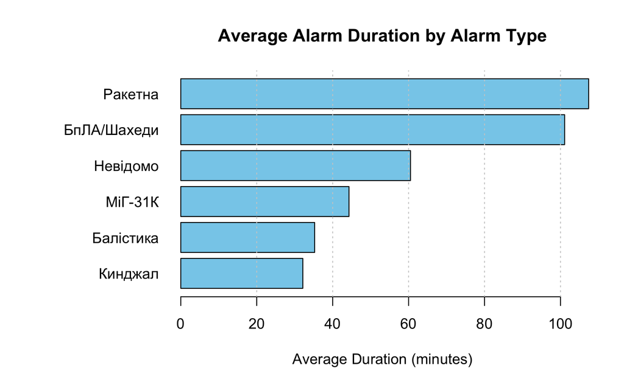

```r
alarm_avg <- aggregate(df$duration_min,
                       by = list(alarm_type = df$alarm_type),
                       FUN = mean, na.rm = TRUE)

colnames(alarm_avg)[2] <- "duration_min"

alarm_avg <- alarm_avg[order(alarm_avg$duration_min), ]

par(mar = c(5, 10, 4, 2))

barplot(alarm_avg$duration_min,
        names.arg = alarm_avg$alarm_type,
        horiz = TRUE,
        las = 1,
        col = "skyblue",
        border = "black",
        main = "Average Alarm Duration by Alarm Type",
        xlab = "Average Duration (minutes)"
)


abline(v = pretty(alarm_avg$duration_min), col = "gray80", lty = 3)
```

To test dependence between type of alarm and its duration we use 2 approaches Firstly, for or each air alarm type we test such hypothesis using t-test(because variance of data is unknown):

> $H_0: \mu = \mu_{\text{type}}$, $\quad H_1: \mu \neq \mu_{\text{type}}$

where $\mu$ is the mean of the whole data, and $\mu_{\text{type}}$ is the sample mean of the type

Secondly, we use Kolgomorov-Smirnov test, to compare e.c.d.f. of durations with some specific type of air alarm to e.c.d.f. of the data

$H_0 : F_{\text{type}} = F$

$H_1 : F_{\text{type}} \not= F_y$

```r
y_all <- df$duration_min

ad_pvalue <- function(res, version = 1, type = "asymptotic") {
  col <- ifelse(type == "asymptotic", 3, 4)
  res$ad[version, col]
}

for (type in unique(df$alarm_type)) {

  x <- df$duration_min[df$alarm_type == type]

  y <- df$duration_min[df$alarm_type != type]

  t_test <- t.test(x, y, alternative = "two.sided")
  pval_t <- format(t_test$p.value, scientific = FALSE)

  ks_test <- suppressWarnings(ks.test(x, y, alternative = "two.sided"))
  pval_ks <- format(ks_test$p.value, scientific = FALSE)

  cat("Alarm type:", type, "\n")
  cat("  t-test p =", pval_t, "\n")
  cat("  KS test p =", pval_ks, "\n")
}
```

```
Alarm type: Невідомо
  t-test p = 0.6319486
  KS test p = 0.4520316
Alarm type: МіГ-31К
  t-test p = 0.00000000000002344426
  KS test p = 0.0000000000000003116681
Alarm type: Ракетна
  t-test p = 0.000000002427673
  KS test p = 0.0000000000002504704
Alarm type: БпЛА/Шахеди
  t-test p = 0.00006641761
  KS test p = 0.00000001169248
Alarm type: Балістика
  t-test p = 0.001829862
  KS test p = 0.04100066
Alarm type: Кинджал
  t-test p = 0.00000607535
  KS test p = 0.1429042
```

# 4 Estimation models

## 4.1 Regression

To examine how different factors jointly influence the duration of air alarms, we fit a multiple linear regression model where the response variable is the alarm duration in minutes.$y = a+ b_1\cdot x_1+b_2\cdot x_2 +b_3 \cdot x_3 + b_4 \cdot x_4 + c_1\cdot i_1 + ... + c_5\cdot i_5+ \epsilon$,

Where:  
$b_1$: number of regions with an active air alarm,

$b_2$: start hour,

$b_3$: start year - 2022,

$b_4$: weekday,

$c_j$: for each of the 5 air alarm types (if the air alarm type is active then $i_j$ = 1)

```r
df <- read.csv("datasets/tg_parsed_alarms.csv")
df$started <- ymd_hms(df$started, tz = "UTC")

df$start_hour <- hour(df$started)
df$start_hour <- as.numeric(df$start_hour)
df$start_hour<-df$start_hour+5

df$start_year <- year(df$started)
df$start_year <- as.numeric(df$start_year)
df$start_year <- df$start_year-2022

df$start_weekday <-  (as.integer(strftime(df$started, "%u")) - 1)

df$alarm_type <- as.factor(df$alarm_type)
df$duration_min <- as.numeric(df$duration_min)

df$regions_n <- sapply(strsplit(df$alarms_in_regions, ";"), function(x) length(trimws(x)))
```

```r
f_lm<-lm(formula=duration_min ~ regions_n+alarm_type+start_hour+start_year+start_weekday,data=df)
summary(f_lm)
```

```
Call:
lm(formula = duration_min ~ regions_n + alarm_type + start_hour +
    start_year + start_weekday, data = df)

Residuals:
    Min      1Q  Median      3Q     Max
-124.01  -25.04  -13.05   15.70  234.82

Coefficients:
                      Estimate Std. Error t value Pr(>|t|)
(Intercept)           -50.9612    24.3802  -2.090   0.0371 *
regions_n               4.6520     0.8703   5.345 1.42e-07 ***
alarm_typeБпЛА/Шахеди 100.6459    15.9836   6.297 7.09e-10 ***
alarm_typeКинджал      -8.3213    25.4847  -0.327   0.7442
alarm_typeМіГ-31К       2.9851    13.5844   0.220   0.8262
alarm_typeНевідомо     22.3460    14.6570   1.525   0.1280
alarm_typeРакетна      64.4845    14.3633   4.490 9.03e-06 ***
start_hour             -0.4642     0.3263  -1.422   0.1556
start_year             -4.7129     3.2022  -1.472   0.1418
start_weekday           1.2635     1.2458   1.014   0.3110
---
Signif. codes:  0 ‘***’ 0.001 ‘**’ 0.01 ‘*’ 0.05 ‘.’ 0.1 ‘ ’ 1

Residual standard error: 48.86 on 461 degrees of freedom
Multiple R-squared:  0.2733,    Adjusted R-squared:  0.2591
F-statistic: 19.27 on 9 and 461 DF,  p-value: < 2.2e-16
```

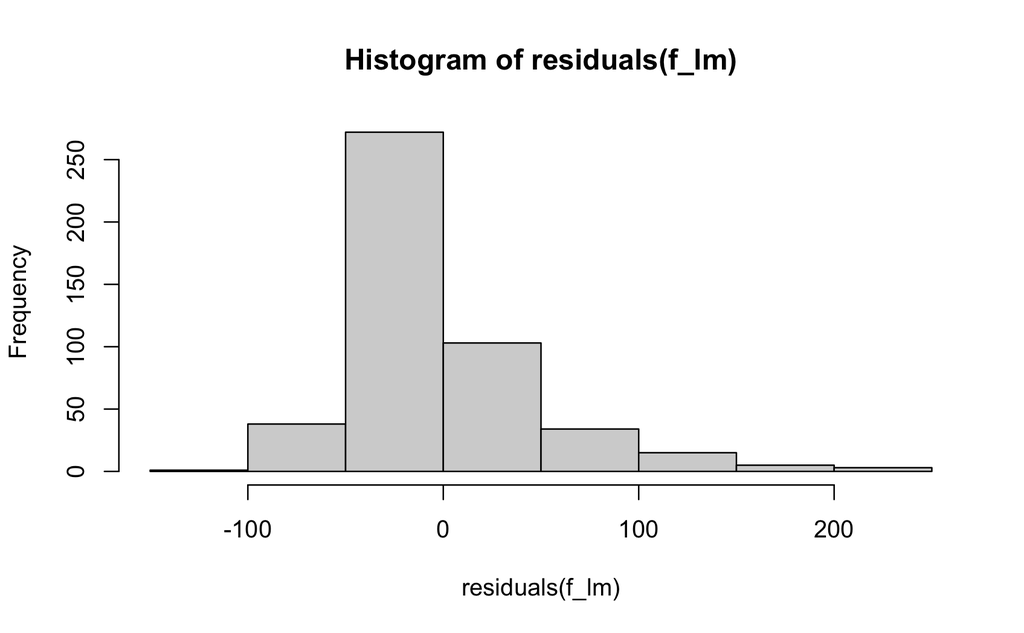

```r
hist(residuals(f_lm))
```

And to improve regression model we removed outliers.

```r
model_pr <- lm(duration_min ~ regions_n+alarm_type+start_hour+start_year+start_weekday, data=df)
res <- rstandard(model_pr)
df_clean <- df[abs(res) < 3, ]
f_lm <- lm(duration_min ~ regions_n+alarm_type+start_hour+start_year+start_weekday, data=df_clean)
summary(f_lm)
```

```
Call:
lm(formula = duration_min ~ regions_n + alarm_type + start_hour +
    start_year + start_weekday, data = df_clean)

Residuals:
    Min      1Q  Median      3Q     Max
-121.45  -21.63  -10.94   13.67  143.47

Coefficients:
                      Estimate Std. Error t value Pr(>|t|)
(Intercept)           -30.6850    20.4208  -1.503   0.1336
regions_n               4.3151     0.7297   5.913 6.64e-09 ***
alarm_typeБпЛА/Шахеди  91.6284    13.3443   6.866 2.19e-11 ***
alarm_typeКинджал      -8.1320    21.0558  -0.386   0.6995
alarm_typeМіГ-31К      -0.4153    11.2306  -0.037   0.9705
alarm_typeНевідомо     15.5161    12.1587   1.276   0.2026
alarm_typeРакетна      54.3703    11.9249   4.559 6.62e-06 ***
start_hour             -0.8731     0.2766  -3.157   0.0017 **
start_year             -6.3057     2.7021  -2.334   0.0201 *
start_weekday           0.4534     1.0402   0.436   0.6631
---
Signif. codes:  0 ‘***’ 0.001 ‘**’ 0.01 ‘*’ 0.05 ‘.’ 0.1 ‘ ’ 1

Residual standard error: 40.37 on 450 degrees of freedom
Multiple R-squared:  0.3253,    Adjusted R-squared:  0.3118
F-statistic: 24.11 on 9 and 450 DF,  p-value: < 2.2e-16
```

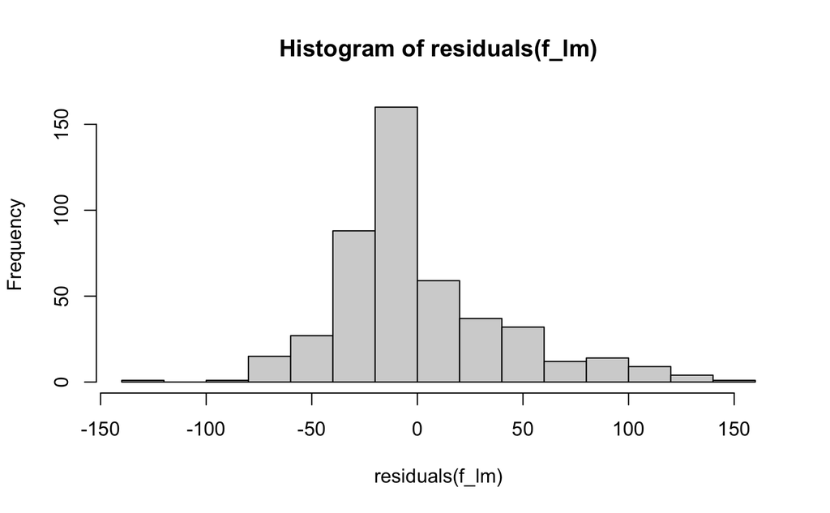

```r
hist(residuals(f_lm))
```

The regression results show that several factors have a statistically significant effect on alarm duration. The number of affected regions strongly increases duration (p < .001). Among alarm types, “БпЛА/Шахеди” and “Ракетна” seem to have way significant impact on air alarm duration (p < .001), while other types do not.

Overall, the model explains about 32% of the variance (R^2 = 0.325), suggesting that these factors jointly capture a meaningful part of the variation in alarm durations.

## 4.2 Lognormal Distribution:

A random variable X is lognormally distributed if its logarithm is normally distributed: $\ln X \sim \mathcal{N}(\mu, \sigma^{2})$

In our case it fits well, because our data: - Cannot be negative - Most are small, few are extremely large - Heavy right tail

and it is predictable, because lognormal distribution is mostly applicable in: - Durations (waiting times, alarm durations, time until something finishes) - Income distribution - Stock prices - Biological growth

It’s PDF:

f(x) = $\frac{1}{x \, \sigma \sqrt{2\pi}} \exp!\left( -\frac{(\ln x - \mu)^{2}}{2\sigma^{2}} \right), \qquad x \> 0$

## 4.3 fitdist()

fitdist() is a function from fitdistrplus package, that can fit distribution for given data using MLE or MME, by default it uses MLE to estimate parameters of distribution, we want to fit.

Also it shows estimated standard deviation of the estimator, which is basically shows us the precision of estimator

gofstat() is also a funciton from fitdistrplus package, that cumputes goodness-of-fit statistics for fitted dsitributions. It compares fitted dsitrubions via Kolmogorov-Smirnov statistic, Cramer-von Mises statistic, Anderson-Darling statistic, Akaike’s Information Criterion, Bayesian Information Criterion:

1. Kolmogorov–Smirnov statistic: measures supremum of distances between the empirical CDF of data and the fitted distribution’s CDF D = $\sup\_{x} \left\| F_n(x) - F(x \mid \theta) \right\|$
2. Cramer-von Mises statistic measures integrated squared distance between empirical CDF and fitted distribution’s CDF $\omega^2$ = $\int_{-\infty}^{\infty} \left( F_n(x) - F(x) \right)^2 \, dF(x)$
3. Anderson-Darling statistic the same as Cramer-von Mises statistic, but the integrated squared distance is divided by F(x)(1 - F(x)), which gives more weight to tails
   $$A^2
   =
   \int_{-\infty}^{\infty}
   \frac{ \left( F_n(x) - F(x) \right)^2 }
   { F(x)\bigl(1 - F(x)\bigr) }
   \, dF(x)$$
4. Akaike Information Criterion(AIC): AIC = −2logL+2k, where L - log likelihood, k - number of parameters(as an example for exponential 1 parameter (rate), for normal(mean, sd) or lognormal(meanlog, sdlog) - 2, it is usefull as it penalizes overfitting (when distribution has to many parameters, it basically can “memorize” the data, and starts matching random noise in data, but not the pattern of it)
5. Bayesian Information Criterion (BIC): BIC = 2logL+klogn. penalizes number of parameters even stronger, and tells, that simplier distributions are better, if fits are similar

In all of this Goodness-of-fit tests and criteria, to choose the best-fitting distribution we have to choose one, with the smallest value of test statistic, and according to all of those tests and criteria, we can state, that lognormal is the closest distribution to our observed data